# Youtube Trending Videos

# Introduction

This dataset includes data of trending videos on Youtube (01/12/2017 - 31/05/2018).

There are 16 variables in total.  
Numeric:  
views, likes, dislikes, comment_count  
Categorical:  
channel_title, category_id, tags, comments_disabled, ratings_disabled, video_error_or_removed  
Time:  
trending_date, publish_time  
Other:  
video_id, title, thumbnail_link, description

Each video may be put on the trending list more than once.

# Thinking before Analysis

Since each video can show up several times in this dataset, lots of repetitive information exists. Moreover, all the numeric variables are cumulative, which means certain data processing methods are needed for the growth analysis concerning these variables.

# How to Be Trending

In my opinion, the value of each video follows this equation:  
value = number of views * view duration.

Trending list is to provide users with the hottest videos in the past period (here we use a day), which can help those popular videos obtain more attention. Therefore, cumulative views and views growth rate are two important parameters to determine whether a video could be put on the trending list or not. The following analysis will focus on relationships between different independent variables and the number of views.

# Data Processing

## Read data and load packages

```r
library(tidyverse)
library(lubridate)
youtube_orig <- read.csv("~/courses/mod1/intro_ba/team/youtube1.csv")
youtube <- youtube_orig
```

## Select the first trending data for each video (to avoid time-series influence)

```r
youtube_first_trending <- youtube %>%
  group_by(video_id) %>%
  mutate(first_trending = min(ydm(trending_date))) %>%
  filter(ydm(trending_date) == first_trending) %>%
  separate(publish_time, c("date","time"), sep="T") %>%
  filter(date>="2017-12-01") %>%
  dplyr::select(video_id, trending_date, date, time,title, channel_title, category_id, views,likes, dislikes, comment_count,tags) %>%
  distinct()
```

# Two-sample T-Test

## Video Views at Weekends vs. Weekdays

H0: Trending videos have the same number of views during weekdays and weekends.  
H1: Trending videos have different numbers of views during weekdays and weekends.

```r
youtube_ttest <- youtube_first_trending %>%
  mutate(week_day = weekdays(ymd(date))) %>%
  mutate(weekend=ifelse((week_day=="Saturday" | week_day=="Sunday"),1,0))

t.test(youtube_ttest$views ~ youtube_ttest$weekend,
       alternative = "two.sided", var.equal = TRUE)
```

```
##
##  Two Sample t-test
##
## data:  youtube_ttest$views by youtube_ttest$weekend
## t = -0.57401, df = 5122, p-value = 0.566
## alternative hypothesis: true difference in means is not equal to 0
## 95 percent confidence interval:
##  -207958.3  113759.9
## sample estimates:
## mean in group 0 mean in group 1
##        903171.8        950271.0
```

## Summary

The t-test has a p-value of 0.566, which is far larger than 0.05, the pre-decided significance level. Therefore, the H0 can’t be rejected, and trending videos tend to have the same number of views during weekday and weekend.

# Anova Test

## Video Views and Category ID

H0: Trending videos have the same number of views across different categories.  
H1: Trending videos have different numberd of views across different categories.

```r
categoryTest <- aov(data = youtube_first_trending, views~as.factor(category_id))
summary(categoryTest)
```

```
##                          Df    Sum Sq   Mean Sq F value Pr(>F)
## as.factor(category_id)   15 9.143e+14 6.096e+13   12.46 <2e-16 ***
## Residuals              5108 2.498e+16 4.891e+12
## ---
## Signif. codes:  0 '***' 0.001 '**' 0.01 '*' 0.05 '.' 0.1 ' ' 1
```

```r
TukeyHSD(categoryTest)
```

```
##   Tukey multiple comparisons of means
##     95% family-wise confidence level
##
## Fit: aov(formula = views ~ as.factor(category_id), data = youtube_first_trending)
##
## $`as.factor(category_id)`
##                diff         lwr          upr     p adj
## 2-1    -740489.9144 -1911876.50   430896.670 0.7206363
## 10-1    543012.9762   -18102.04  1104127.988 0.0704164
## 15-1   -925429.9848 -1772885.08   -77974.887 0.0170821
## 17-1   -243312.2550  -861688.61   375064.103 0.9940309
## 19-1   -994647.9144 -2166034.50   176738.670 0.2098810
## 20-1    157764.5890  -759135.41  1074664.591 0.9999998
## 22-1   -396590.4703  -999304.29   206123.354 0.6570303
## 23-1   -396911.2513  -990858.36   197035.861 0.6308456
## 24-1   -309496.4242  -825882.55   206889.701 0.7939473
## 25-1   -946659.0337 -1550523.04  -342795.030 0.0000095
## 26-1   -715678.8993 -1299424.40  -131933.399 0.0028207
## 27-1   -865376.8991 -1572754.32  -157999.478 0.0029305
## 28-1   -598233.5771 -1242906.09    46438.936 0.1046535
## 29-1    126253.8256 -2112473.24  2364980.886 1.0000000
## 43-1   -857047.1744 -4676758.48  2962664.129 0.9999935
## 10-2   1283502.8906   169279.18  2397726.596 0.0078920
## 15-2   -184940.0703 -1467447.21  1097567.065 1.0000000
## 17-2    497177.6594  -646952.46  1641307.779 0.9838366
## 19-2   -254158.0000 -1770334.42  1262018.421 0.9999999
## 20-2    898254.5034  -431162.67  2227671.678 0.6116742
## 22-2    343899.4442  -791841.88  1479640.772 0.9996961
## 23-2    343578.6631  -787534.76  1474692.089 0.9996842
## 24-2    430993.4902  -661388.79  1523375.768 0.9938585
## 25-2   -206169.1193 -1342521.24   930183.003 0.9999996
## 26-2     24811.0152 -1100979.03  1150601.057 1.0000000
## 27-2   -124886.9846 -1319469.43  1069695.464 1.0000000
## 28-2    142256.3373 -1016297.53  1300810.203 1.0000000
## 29-2    866743.7400 -1570168.91  3303656.390 0.9980010
## 43-2   -116557.2600 -4055699.15  3822584.632 1.0000000
## 15-10 -1468442.9610 -2234946.76  -701939.159 0.0000000
## 17-10  -786325.2312 -1288059.48  -284590.983 0.0000096
## 19-10 -1537660.8906 -2651884.60  -423437.185 0.0002604
## 20-10  -385248.3872 -1227895.14   457398.366 0.9740014
```

[output cut: 72 more lines]

```
## 26-25   230980.1344  -278832.01   740792.280 0.9760695
## 27-25    81282.1346  -566431.10   728995.367 1.0000000
## 28-25   348425.4566  -230152.34   927003.251 0.7879575
## 29-25  1072912.8593 -1147683.56  3293509.281 0.9576328
## 43-25    89611.8593 -3719501.43  3898725.149 1.0000000
## 27-26  -149697.9998  -778696.81   479300.811 0.9999858
## 28-26   117445.3222  -440102.29   674992.932 0.9999972
## 29-26   841932.7248 -1373277.32  3057142.769 0.9958635
## 43-26  -141368.2752 -3947343.99  3664607.438 1.0000000
## 28-27   267143.3220  -418774.56   953061.207 0.9946377
## 29-27   991630.7246 -1259320.09  3242581.535 0.9815825
## 43-27     8329.7246 -3818558.72  3835218.165 1.0000000
## 29-28   724487.4027 -1507551.88  2956526.690 0.9993015
## 43-28  -258813.5973 -4074609.05  3556981.859 1.0000000
## 43-29  -983301.0000 -5360125.32  3393523.325 0.9999934
```

## Summary

The result of the ANOVA test shows a p-value that is greatly smaller than 0.05, the pre-decided significance level. Therefore, the H0 should be rejected, and trending videos tend to have different numbers of views across different categories.

# Regression Model

## Relationship between video views and number of tags

$$Views\ = \beta_0\ + \beta_1\ * Num\ of\ Tags$$
$$H_0: \beta_1\ = 0$$
$$H_1: \beta_1\ != 0$$

```r
youtube_tags <- youtube_first_trending %>%
  mutate(tags = as.character(tags)) %>%
  mutate(numTags = ifelse((tags == "[none]"),
                          0, str_count(tags, "\\|")+1))

model_tags <- lm(data = youtube_tags, views~numTags)
summary(model_tags)
```

```
##
## Call:
## lm(formula = views ~ numTags, data = youtube_tags)
##
## Residuals:
##      Min       1Q   Median       3Q      Max
## -1209746  -778166  -581419   -27130 47494901
##
## Coefficients:
##             Estimate Std. Error t value Pr(>|t|)
## (Intercept)   779531      60668  12.849   <2e-16 ***
## numTags         6551       2576   2.544    0.011 *
## ---
## Signif. codes:  0 '***' 0.001 '**' 0.01 '*' 0.05 '.' 0.1 ' ' 1
##
## Residual standard error: 2247000 on 5122 degrees of freedom
## Multiple R-squared:  0.001261,   Adjusted R-squared:  0.001066
## F-statistic: 6.469 on 1 and 5122 DF,  p-value: 0.011
```

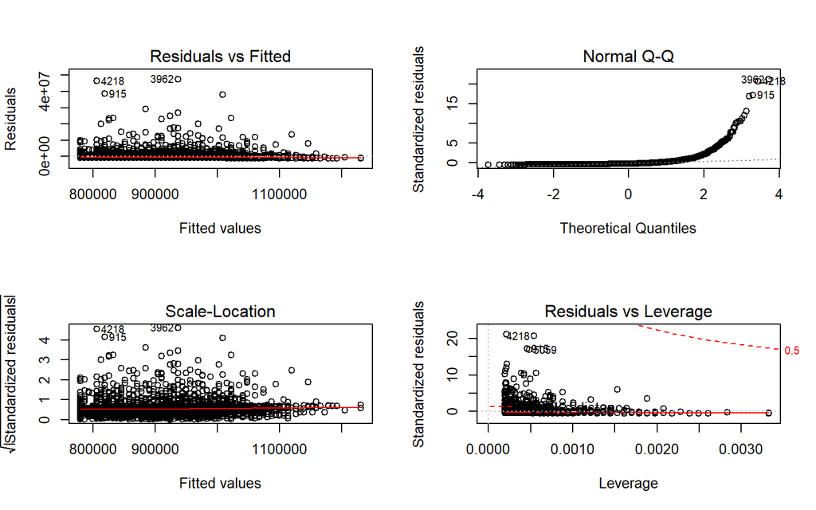

```r
par(mfrow = c(2, 2))
plot(model_tags)
```

## Summary

The coefficient has a 0.011 p-value that is smaller than 0.05, the pre-decided significance level. Thus, the H0 should be rejected, and the number of tags for a video can positively influence its number of views.

However, the following plots show that residuals are not normally distributed, and the r-square is only 0.001261. The F-statistic is 6.469, which also means this model is not a good fit to the dataset.

# Revised Regression Model

## Use music and news category as dummy variables

$$Views\ = \beta_0\ + \beta_1\ * Num\ of\ Tags\ + \beta_2\ * Dummy_{music}\ +\beta_3\ *\ Dummy_{news}$$
$$H_0: \beta_1\ = 0,\ \beta_2\ = 0,\ \beta_3\ = 0$$
$$H_1: \beta_1\ != 0,\ \beta_2\ != 0,\ \beta_3\ != 0$$

```r
youtube_dummy <- youtube_tags %>%
  mutate(music = ifelse(category_id == 10, TRUE, FALSE)) %>%
  mutate(news = ifelse(category_id == 25, TRUE, FALSE))

model <- lm(data = youtube_dummy, views~numTags+music+news)
summary(model)
```

```
##
## Call:
## lm(formula = views ~ numTags + music + news, data = youtube_dummy)
##
## Residuals:
##      Min       1Q   Median       3Q      Max
## -2054061  -711033  -471077    41170 46522836
##
## Coefficients:
##             Estimate Std. Error t value Pr(>|t|)
## (Intercept)   602220      66246   9.091  < 2e-16 ***
## numTags        10827       2615   4.141 3.52e-05 ***
## musicTRUE    1046748      97401  10.747  < 2e-16 ***
## newsTRUE     -459943     116592  -3.945 8.09e-05 ***
## ---
## Signif. codes:  0 '***' 0.001 '**' 0.01 '*' 0.05 '.' 0.1 ' ' 1
##
## Residual standard error: 2216000 on 5120 degrees of freedom
## Multiple R-squared:  0.02879,    Adjusted R-squared:  0.02822
## F-statistic: 50.59 on 3 and 5120 DF,  p-value: < 2.2e-16
```

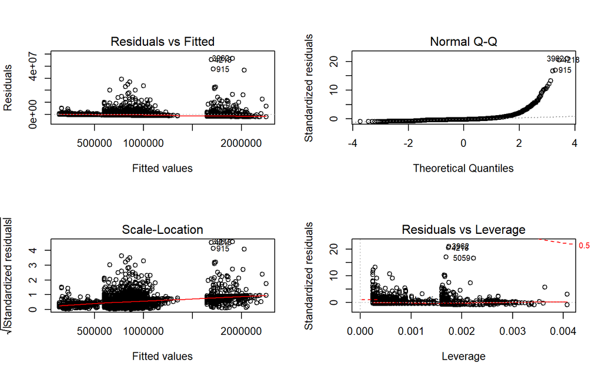

```r
par(mfrow = c(2, 2))
plot(model)
```

## Summary

All three coefficients have p-values that are smaller than 0.05, the pre-decided significance level. Thus, the H0 should be rejected, and the number of tags and the music dummy has a positive impact on video views, while the news dummy has a negative one.

# Limitations

1. This dataset doesn’t include data of those videos falling out of the trending list, which can be utilized to determine the views threshold of the trending list.
2. This analysis assumes the trending list is daily updated, while it actually may be updated every 15 minutes. This proxy leads to inaccuracy.
3. The revised model still doesn’t have a high r-square and F-statistic, which means further analysis is needed to explore the relationship.

Jie Liu

10/9/2019